# DEM 7263 - Spatially Autoregressive Models part 2

Corey S. Sparks, Ph.D.

27 September, 2021

```r
knitr::opts_chunk$set(error = TRUE)
```

```r
library(nortest)
library(car)
library(lmtest)
library(classInt)
library(sandwich)
library(tidyverse)
library(spdep)
library(spatialreg)
library(sf)
```

# Spatial Regression Models

This lecture builds off the previous lecture on the Spatially Autoregressive Model (SAR) with either a lag or error specification.

The lag model is written: $Y= \rho W Y + X '\beta +e$

Where Y is the dependent variable, X is the matrix of independent variables, $\beta$ is the vector of regression parameters to be estimated from the data, $\rho$ is the *autoregressive* coefficient, which tells us how strong the resemblance is, on average, between $Y_i$ and it’s neighbors. The matrix **W** is the spatial weight matrix, describing the spatial network structure of the observations, like we described in the ESDA lecture.

In the lag model, we are specifying the spatial component on the dependent variable. This leads to a spatial filtering of the variable, where they are averaged over the surrounding neighborhood defined in **W**, called the spatially lagged variable. In R we use the spdep package, and the `lagsarlm()` function to fit this model.

The error model says that the autocorrelation is not in the outcome itself, but instead, any autocorrelation is attributable to there being missing *spatial covariates* in the data. If these spatially patterned covariates *could* be measures, then the autocorrelation would be 0. This model is written:

$Y= X' \beta +e$

$e=\lambda W e + v$

This model, in effect, controls for the nuisance of correlated errors in the data that are attributable to an inherently spatial process, or to spatial autocorrelation in the measurement errors of the measured and possibly unmeasured variables in the model. This model is estimated in R using `errorsarlm()` in the `spdep` library.

## Examination of Model Specification

To some degree, both of the SAR specifications allow us to model spatial dependence in the data. The primary difference between them is where we model said dependence.

The lag model says that the dependence affects the dependent variable only, we can liken this to a diffusion scenario, where your neighbors have a diffusive effect on you.

The error model says that dependence affects the residuals only. We can liken this to the missing spatially dependent covariate situation, where, if only we could measure another really important spatially associated predictor, we could account for the spatial dependence. But alas, we cannot, and we instead model dependence in our errors.

These are inherently two completely different ways to think about specifying a model, and we should really make our decision based upon how we think our process of interest operates.

That being said, this way of thinking isnt necessarily popular among practitioners. Most practitioners want the *best fitting model*,’nuff said. So methods have been developed that test for alternate model specifications, to see which kind of model best summarizes the observed variation in the dependent variable and the spatial dependence.

## More exotic types of spatial dependence

**Spatial Durbin Model** Another form of a spatial lag model is the **Spatial Durbin Model** (SDM). This model is an extension of the ordinary lag or error model that includes spatially lagged independent variables. If you remember, one issue that commonly occures with the lag model, is that we often have residual autocorrelation in the model. This autocorrelation could be attributable to a missing spatial covariate. We *can* get a kind of spatial covariate by lagging the predictor variables in the model using **W**. This model can be written:

$Y= \rho W Y + X '\beta + W X \theta + e$

Where, the $\theta$ parameter vector are now the regression coefficients for the lagged predictor variables. We can also include the lagged predictors in an error model, which gives us the **Durbin Error Model** (DEM):

$Y= X '\beta + W X \theta + e$

$e=\lambda W e + v$

Generally, the spatial Durbin model is preferred to the ordinary error model, because we can include the *unspecified spatial covariates* from the error model into the Durbin model via the lagged predictor variables.

**Spatially Autoregressive Moving Average Model** Futher extensions of these models include dependence on both the outcome and the error process. Two models are described in [LeSage and Pace](https://books.google.com/books?id=EKiKXcgL-D4C&hl=en). The **Spatial Autocorrelation Model**, or SAC model and the **Spatially autoregressive moving average** model (SARMA model). The SAC model is:

$Y= \rho W_1 Y + X '\beta + e$

$e=\theta W_2 e + v$

$Y= (I_n - \rho W_1)^{-1} X '\beta + (I_n - \rho W_1)^{-1} (I_n - \theta W_2)^{-1} e$

Where, you can potentially have two different spatial weight matrices, $W_1$ and $W_2$. Here, the lagged error term is taken over all orders of neighbors, leading to a more *global* error process, while the SARMA model has form:

$Y= \rho W_1 Y + X '\beta + u$

$u=(I_n - \theta W_2) e$

$e \sim N(0, \sigma^2 I_n)$

$Y= (I_n - \rho W_1)^{-1} X '\beta + (I_n - \rho W_1)^{-1} (I_n - \theta W_2) e$

which gives a “locally” weighted moving average to the residuals, which will avereage the residuals only in the local neighborhood, instead of over all neighbor orders.

Fitting these models in R can be done in the `spdep` library.

```r
spdat<-st_read("../data/PSP_Data_CLnad83.shp")
#Create a k=2 nearest neighbor set
us.nb5<-knearneigh(st_coordinates(st_centroid(spdat))[, 1:2], k=2, longlat = T)
us.nb5<-knn2nb(us.nb5)
us.wt2<-nb2listw(make.sym.nb(us.nb5), style="W")


nbs<-poly2nb(spdat, queen = T)
nbs
```

```
## Neighbour list object:
## Number of regions: 3071
## Number of nonzero links: 18016
## Percentage nonzero weights: 0.1910288
## Average number of links: 5.866493
## 5 regions with no links:
## 1186 1192 1836 2897 2910
```

```r
us.lw<-nb2listw(make.sym.nb(nbs), zero.policy = T)
```

Next, we scale the outcomes and predictors:

```r
spdat$mortz<-scale(spdat$ARSMORT, center=T, scale=T)
spdat$densz<-scale(spdat$PDENSITY, center=T, scale=T)
spdat$rurz<-scale(spdat$PRURAL, center=T, scale=T)
spdat$blacz<-scale(spdat$PBLACK, center=T, scale=T)
spdat$hisz<-scale(spdat$PHISP, center=T, scale=T)
spdat$femz<-scale(spdat$FEMHH, center=T, scale=T)
spdat$unemz<-scale(spdat$UNEMP, center=T, scale=T)
spdat$povz<-scale(spdat$PPERSONPO, center=T, scale=T)
spdat$incz<-scale(spdat$MEDHHINC, center=T, scale=T)
spdat$hvalz<-scale(spdat$MEDHVAL, center=T, scale=T)
spdat$giniz<-scale(spdat$GINI001, center=T, scale=T)
```

Moran’s I for the mortality rate:

```r
moran.test(spdat$mortz,
           listw = us.lw ,
           zero.policy = T)
```

```
##
##  Moran I test under randomisation
##
## data:  spdat$mortz
## weights: us.lw  n reduced by no-neighbour observations
##
##
## Moran I statistic standard deviate = 47.396, p-value < 2.2e-16
## alternative hypothesis: greater
## sample estimates:
## Moran I statistic       Expectation          Variance
##      0.5087738773     -0.0003262643      0.0001153784
```

## Models

Now we show how to fit the various models described above. We start with OLS and move through the various other models.

```r
fit.ols<-lm(mortz~rurz+blacz+hisz+unemz+hvalz+densz+giniz,data=spdat)
summary(fit.ols)
```

```
##
## Call:
## lm(formula = mortz ~ rurz + blacz + hisz + unemz + hvalz + densz +
##     giniz, data = spdat)
##
## Residuals:
##     Min      1Q  Median      3Q     Max
## -4.3588 -0.5376  0.0029  0.5319  6.9022
##
## Coefficients:
##               Estimate Std. Error t value Pr(>|t|)
## (Intercept) -2.519e-16  1.542e-02   0.000 1.000000
## rurz        -1.775e-01  1.790e-02  -9.915  < 2e-16 ***
## blacz        1.825e-01  1.762e-02  10.355  < 2e-16 ***
## hisz        -1.819e-01  1.694e-02 -10.742  < 2e-16 ***
## unemz        1.414e-01  1.709e-02   8.271  < 2e-16 ***
## hvalz       -2.749e-01  1.877e-02 -14.648  < 2e-16 ***
## densz        6.496e-02  1.728e-02   3.758 0.000174 ***
## giniz        2.288e-01  1.741e-02  13.141  < 2e-16 ***
## ---
## Signif. codes:  0 '***' 0.001 '**' 0.01 '*' 0.05 '.' 0.1 ' ' 1
##
## Residual standard error: 0.8543 on 3063 degrees of freedom
## Multiple R-squared:  0.2719, Adjusted R-squared:  0.2702
## F-statistic: 163.4 on 7 and 3063 DF,  p-value: < 2.2e-16
```

```r
lm.morantest(fit.ols, listw=us.wt2)
```

```
##
##  Global Moran I for regression residuals
##
## data:
## model: lm(formula = mortz ~ rurz + blacz + hisz + unemz + hvalz + densz
## + giniz, data = spdat)
## weights: us.wt2
##
## Moran I statistic standard deviate = 25.407, p-value < 2.2e-16
## alternative hypothesis: greater
## sample estimates:
## Observed Moran I      Expectation         Variance
##     0.4104661697    -0.0016276333     0.0002630811
```

```r
set.seed(1234)
```

### SAR - Lag model

```r
fit.lag<-lagsarlm(mortz~rurz+blacz+hisz+unemz+hvalz+densz+giniz,
                  spdat,
                  listw=us.wt2,
                  type="lag")
summary(fit.lag, Nagelkerke=T)
```

```
##
## Call:lagsarlm(formula = mortz ~ rurz + blacz + hisz + unemz + hvalz +
##     densz + giniz, data = spdat, listw = us.wt2, type = "lag")
##
## Residuals:
##        Min         1Q     Median         3Q        Max
## -5.2648068 -0.4321005 -0.0056475  0.4227876  7.1589340
##
## Type: lag
## Coefficients: (asymptotic standard errors)
##                Estimate  Std. Error  z value  Pr(>|z|)
## (Intercept)  0.00080657  0.01335846   0.0604    0.9519
## rurz        -0.16765578  0.01553074 -10.7951 < 2.2e-16
## blacz        0.09505873  0.01557041   6.1051 1.027e-09
## hisz        -0.11716731  0.01479758  -7.9180 2.442e-15
## unemz        0.11085699  0.01490520   7.4375 1.026e-13
## hvalz       -0.22697053  0.01656962 -13.6980 < 2.2e-16
## densz        0.06109036  0.01499748   4.0734 4.634e-05
## giniz        0.16366568  0.01521538  10.7566 < 2.2e-16
##
## Rho: 0.41656, LR test value: 647.2, p-value: < 2.22e-16
## Asymptotic standard error: 0.015903
##     z-value: 26.194, p-value: < 2.22e-16
## Wald statistic: 686.15, p-value: < 2.22e-16
##
## Log likelihood: -3546.274 for lag model
## ML residual variance (sigma squared): 0.54801, (sigma: 0.74028)
## Nagelkerke pseudo-R-squared: 0.41023
## Number of observations: 3071
## Number of parameters estimated: 10
## AIC: 7112.5, (AIC for lm: 7757.8)
## LM test for residual autocorrelation
## test value: 51.561, p-value: 6.94e-13
```

### SAR - Error model

```r
fit.err<-errorsarlm(mortz~rurz+blacz+hisz+unemz+hvalz+densz+giniz,
                    spdat,
                    listw=us.wt2,
                    etype="error")
summary(fit.err, Nagelkerke=T)
```

```
##
## Call:errorsarlm(formula = mortz ~ rurz + blacz + hisz + unemz + hvalz +
##     densz + giniz, data = spdat, listw = us.wt2, etype = "error")
##
## Residuals:
##       Min        1Q    Median        3Q       Max
## -5.311914 -0.421874 -0.010637  0.427215  7.047834
##
## Type: error
## Coefficients: (asymptotic standard errors)
##               Estimate Std. Error  z value  Pr(>|z|)
## (Intercept)  0.0014151  0.0238226   0.0594    0.9526
## rurz        -0.1617751  0.0163725  -9.8809 < 2.2e-16
## blacz        0.1436783  0.0221273   6.4933 8.400e-11
## hisz        -0.1240431  0.0219696  -5.6461 1.641e-08
## unemz        0.1392846  0.0181575   7.6709 1.710e-14
## hvalz       -0.2879350  0.0206600 -13.9368 < 2.2e-16
## densz        0.0866728  0.0196341   4.4144 1.013e-05
## giniz        0.1663798  0.0166296  10.0051 < 2.2e-16
##
## Lambda: 0.43888, LR test value: 616.46, p-value: < 2.22e-16
## Asymptotic standard error: 0.016685
##     z-value: 26.303, p-value: < 2.22e-16
## Wald statistic: 691.86, p-value: < 2.22e-16
##
## Log likelihood: -3561.644 for error model
## ML residual variance (sigma squared): 0.54874, (sigma: 0.74077)
## Nagelkerke pseudo-R-squared: 0.4043
## Number of observations: 3071
## Number of parameters estimated: 10
## AIC: 7143.3, (AIC for lm: 7757.8)
```

### Spatial Durbin Model

```r
fit.durb<-lagsarlm(mortz~rurz+blacz+hisz+unemz+hvalz+densz+giniz,
                   spdat,
                   listw=us.wt2,
                   type="mixed")
summary(fit.durb, Nagelkerke=T)
```

```
##
## Call:lagsarlm(formula = mortz ~ rurz + blacz + hisz + unemz + hvalz +
##     densz + giniz, data = spdat, listw = us.wt2, type = "mixed")
##
## Residuals:
##       Min        1Q    Median        3Q       Max
## -4.752122 -0.417580 -0.011873  0.413091  7.148854
##
## Type: mixed
## Coefficients: (asymptotic standard errors)
##               Estimate Std. Error  z value  Pr(>|z|)
## (Intercept)  0.0016549  0.0131758   0.1256   0.90005
## rurz        -0.1778966  0.0166120 -10.7089 < 2.2e-16
## blacz        0.0176459  0.0301961   0.5844   0.55897
## hisz         0.0022310  0.0322696   0.0691   0.94488
## unemz        0.1146217  0.0194505   5.8930 3.793e-09
## hvalz       -0.2997222  0.0234741 -12.7682 < 2.2e-16
## densz        0.1201146  0.0227553   5.2785 1.302e-07
## giniz        0.1646040  0.0169854   9.6909 < 2.2e-16
## lag.rurz     0.0459754  0.0233801   1.9664   0.04925
## lag.blacz    0.0792797  0.0327565   2.4203   0.01551
## lag.hisz    -0.1349361  0.0345106  -3.9100 9.230e-05
## lag.unemz   -0.0420163  0.0241349  -1.7409   0.08170
## lag.hvalz    0.1445063  0.0277363   5.2100 1.888e-07
## lag.densz   -0.1068408  0.0272050  -3.9273 8.592e-05
## lag.giniz    0.0398244  0.0229248   1.7372   0.08236
##
## Rho: 0.42707, LR test value: 617.92, p-value: < 2.22e-16
## Asymptotic standard error: 0.016793
##     z-value: 25.432, p-value: < 2.22e-16
## Wald statistic: 646.77, p-value: < 2.22e-16
##
## Log likelihood: -3509.868 for mixed model
## ML residual variance (sigma squared): 0.53303, (sigma: 0.73009)
## Nagelkerke pseudo-R-squared: 0.42405
## Number of observations: 3071
## Number of parameters estimated: 17
## AIC: 7053.7, (AIC for lm: 7669.7)
## LM test for residual autocorrelation
## test value: 308.81, p-value: < 2.22e-16
```

### Spatial Durbin Error Model

```r
fit.errdurb<-errorsarlm(mortz~rurz+blacz+hisz+unemz+hvalz+densz+giniz,
                        spdat,
                        listw=us.wt2,
                        etype="emixed")
summary(fit.errdurb, Nagelkerke=T)
```

```
##
## Call:errorsarlm(formula = mortz ~ rurz + blacz + hisz + unemz + hvalz +
##     densz + giniz, data = spdat, listw = us.wt2, etype = "emixed")
##
## Residuals:
##       Min        1Q    Median        3Q       Max
## -4.816288 -0.420624 -0.011491  0.415569  7.122315
##
## Type: error
## Coefficients: (asymptotic standard errors)
##               Estimate Std. Error  z value  Pr(>|z|)
## (Intercept)  0.0025371  0.0230000   0.1103 0.9121632
## rurz        -0.1805461  0.0172135 -10.4886 < 2.2e-16
## blacz        0.0595673  0.0261243   2.2801 0.0225989
## hisz        -0.0491853  0.0277787  -1.7706 0.0766253
## unemz        0.1214629  0.0182327   6.6618 2.705e-11
## hvalz       -0.2916765  0.0215953 -13.5065 < 2.2e-16
## densz        0.1095827  0.0210622   5.2028 1.963e-07
## giniz        0.1836913  0.0170447  10.7770 < 2.2e-16
## lag.rurz    -0.0183783  0.0257245  -0.7144 0.4749633
## lag.blacz    0.1150066  0.0308011   3.7338 0.0001886
## lag.hisz    -0.1522858  0.0319956  -4.7596 1.940e-06
## lag.unemz    0.0153465  0.0252910   0.6068 0.5439854
## lag.hvalz    0.0063939  0.0278212   0.2298 0.8182309
## lag.densz   -0.0683772  0.0279382  -2.4474 0.0143873
## lag.giniz    0.1126912  0.0246713   4.5677 4.931e-06
##
## Lambda: 0.42474, LR test value: 594.94, p-value: < 2.22e-16
## Asymptotic standard error: 0.01689
##     z-value: 25.148, p-value: < 2.22e-16
## Wald statistic: 632.42, p-value: < 2.22e-16
##
## Log likelihood: -3521.362 for error model
## ML residual variance (sigma squared): 0.53752, (sigma: 0.73316)
## Nagelkerke pseudo-R-squared: 0.41972
## Number of observations: 3071
## Number of parameters estimated: 17
## AIC: 7076.7, (AIC for lm: 7669.7)
```

### SAC Model

```r
fit.sac<-sacsarlm(mortz~rurz+blacz+hisz+unemz+hvalz+densz+giniz,
                  spdat,
                  listw=us.wt2,
                  type="sac")
summary(fit.sac, Nagelkerke=T)
```

```
##
## Call:sacsarlm(formula = mortz ~ rurz + blacz + hisz + unemz + hvalz +
##     densz + giniz, data = spdat, listw = us.wt2, type = "sac")
##
## Residuals:
##      Min       1Q   Median       3Q      Max
## -5.04039 -0.36712 -0.01796  0.35075  5.88651
##
## Type: sac
## Coefficients: (asymptotic standard errors)
##                Estimate  Std. Error  z value  Pr(>|z|)
## (Intercept)  0.00017313  0.00744841   0.0232 0.9814560
## rurz        -0.11310973  0.01164878  -9.7100 < 2.2e-16
## blacz        0.03609252  0.00958237   3.7666 0.0001655
## hisz        -0.06942027  0.00912084  -7.6112 2.709e-14
## unemz        0.06032448  0.00990731   6.0889 1.137e-09
## hvalz       -0.12863632  0.01152053 -11.1658 < 2.2e-16
## densz        0.03224298  0.00945013   3.4119 0.0006451
## giniz        0.10616098  0.01120594   9.4736 < 2.2e-16
##
## Rho: 0.73037
## Asymptotic standard error: 0.015197
##     z-value: 48.061, p-value: < 2.22e-16
## Lambda: -0.50571
## Asymptotic standard error: 0.024309
##     z-value: -20.803, p-value: < 2.22e-16
##
## LR test value: 795.61, p-value: < 2.22e-16
##
## Log likelihood: -3472.072 for sac model
## ML residual variance (sigma squared): 0.38626, (sigma: 0.6215)
## Nagelkerke pseudo-R-squared: 0.43806
## Number of observations: 3071
## Number of parameters estimated: 11
## AIC: 6966.1, (AIC for lm: 7757.8)
```

### SMA Model

```r
fit.sma<-spautolm(mortz~rurz+blacz+hisz+unemz+hvalz+densz+giniz,
                  spdat,
                  listw=us.wt2,
                  family="SMA")
summary(fit.sma)
```

```
##
## Call: spautolm(formula = mortz ~ rurz + blacz + hisz + unemz + hvalz +
##     densz + giniz, data = spdat, listw = us.wt2, family = "SMA")
##
## Residuals:
##        Min         1Q     Median         3Q        Max
## -5.1044866 -0.4340989 -0.0084718  0.4455388  7.0192534
##
## Coefficients:
##                Estimate  Std. Error  z value  Pr(>|z|)
## (Intercept)  0.00089203  0.01985098   0.0449    0.9642
## rurz        -0.16549088  0.01680987  -9.8449 < 2.2e-16
## blacz        0.16569487  0.02031327   8.1570 4.441e-16
## hisz        -0.15148541  0.01989603  -7.6138 2.665e-14
## unemz        0.14264752  0.01786712   7.9838 1.332e-15
## hvalz       -0.28147092  0.01995287 -14.1068 < 2.2e-16
## densz        0.07767613  0.01907661   4.0718 4.665e-05
## giniz        0.18278074  0.01688816  10.8230 < 2.2e-16
##
## Lambda: 0.35595 LR test value: 466.53 p-value: < 2.22e-16
## Numerical Hessian standard error of lambda: 0.015292
##
## Log likelihood: -3636.609
## ML residual variance (sigma squared): 0.65819, (sigma: 0.81129)
## Number of observations: 3071
## Number of parameters estimated: 10
## AIC: 7293.2
```

##Using the Lagrange Multiplier Test (LMT)

```r
lm.LMtests(fit.ols, listw=us.wt2, test="all")
```

```
##
##  Lagrange multiplier diagnostics for spatial dependence
##
## data:
## model: lm(formula = mortz ~ rurz + blacz + hisz + unemz + hvalz + densz
## + giniz, data = spdat)
## weights: us.wt2
##
## LMerr = 639.1, df = 1, p-value < 2.2e-16
##
##
##  Lagrange multiplier diagnostics for spatial dependence
##
## data:
## model: lm(formula = mortz ~ rurz + blacz + hisz + unemz + hvalz + densz
## + giniz, data = spdat)
## weights: us.wt2
##
## LMlag = 674.99, df = 1, p-value < 2.2e-16
##
##
##  Lagrange multiplier diagnostics for spatial dependence
##
## data:
## model: lm(formula = mortz ~ rurz + blacz + hisz + unemz + hvalz + densz
## + giniz, data = spdat)
## weights: us.wt2
##
## RLMerr = 8.1365, df = 1, p-value = 0.004338
##
##
##  Lagrange multiplier diagnostics for spatial dependence
##
## data:
## model: lm(formula = mortz ~ rurz + blacz + hisz + unemz + hvalz + densz
## + giniz, data = spdat)
## weights: us.wt2
##
## RLMlag = 44.021, df = 1, p-value = 3.248e-11
##
##
##  Lagrange multiplier diagnostics for spatial dependence
##
## data:
## model: lm(formula = mortz ~ rurz + blacz + hisz + unemz + hvalz + densz
## + giniz, data = spdat)
## weights: us.wt2
##
## SARMA = 683.12, df = 2, p-value < 2.2e-16
```

Of course, the AIC is also your friend:

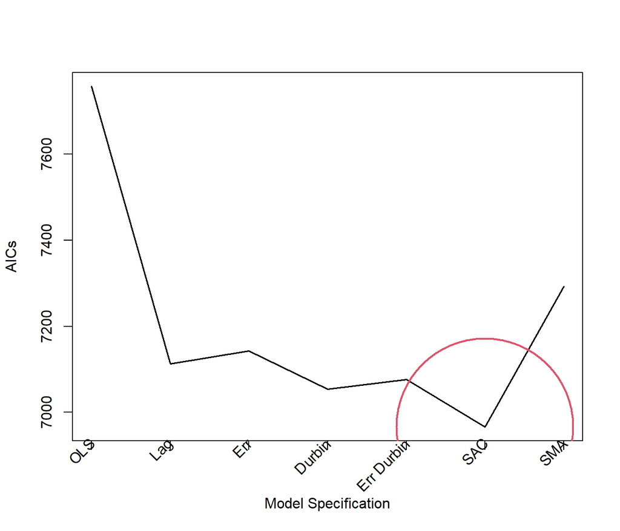

```r
AICs<-c(AIC(fit.ols),AIC(fit.lag), AIC(fit.err), AIC(fit.durb), AIC(fit.errdurb), AIC(fit.sac), AIC(fit.sma))
plot(AICs, type="l", lwd=1.5, xaxt="n", xlab="")
axis(1, at=1:7,labels=F) #6= number of models
labels<-c("OLS", "Lag","Err", "Durbin","Err Durbin", "SAC", "SMA" )
text(1:7, par("usr")[3]-.25, srt=45, adj=1, labels=labels, xpd=T)
mtext(side=1, text="Model Specification", line=3)
symbols(x= which.min(AICs), y=AICs[which.min(AICs)], circles=1, fg=2,lwd=2,add=T)
```

```r
knitr::kable(data.frame(Models=labels, AIC=round(AICs, 2)))
```

| Models | AIC |
| --- | --- |
| OLS | 7757.75 |
| Lag | 7112.55 |
| Err | 7143.29 |
| Durbin | 7053.74 |
| Err Durbin | 7076.72 |
| SAC | 6966.14 |
| SMA | 7293.22 |

```r
anova(fit.sac, fit.durb)
```

|  | Model | df | AIC | logLik | Test | L.Ratio | p-value |
| --- | --- | --- | --- | --- | --- | --- | --- |
| fit.sac | 1 | 11 | 6966.143 | -3472.072 |  | NA | NA |
| fit.durb | 2 | 17 | 7053.736 | -3509.868 | 1 vs 2 | 75.59292 | 2.897682e-14 |

Which indicates that the SAC model fits significantly better than the Durbin model. **SAC it is!!**

## Interpreting effects in spatial lag models

In **spatial lag models**, interpretation of the regression effects is complicated. Each observation will have a direct effect of its predictors, but each observation will also have in indirect effect of the information of its neighbors, although Spatial Error models do not have this issue. In OLS, the impact/effect of a predictor is straight forward:

$$\frac {\delta y_i} {\delta x_{ik}} = \beta_k$$
and

$$\frac {\delta y_i} {\delta x_{jk}} = 0$$

but when a model has a spatial lag of either the outcome or a predictor, this becomes more complicated, indeed:

$$\frac {\delta y_i} {\delta x_{jk}}$$

may not = 0,

or
$$\frac {\delta y_i} {\delta x_{jk}} = S_r(W)$$
, where
$$S_r(W) = (I_n - \rho W)^{-1} \beta_k$$

This implies that a change in the ith regions predictor can affect the jth regions outcome

- We have 2 situations:
- $S_r(W)_{ii}$, or the direct impact of an observation’s predictor on its own outcome, and:
- $S_r(W)_{ij}$, or the *indirect impact* of an observation’s neighbor’s predictor on its outcome.

This leads to three quantities that we want to know:

- *Average Direct Impact*, which is similar to a traditional interpretation
- *Average Total impact*, which would be the total of direct and indirect impacts of a predictor on ones outcome
- *Average Indirect impact*, which would be the average impact of ones neighbors on ones outcome

```r
W <- as(us.wt2, "CsparseMatrix")
trMC <- trW(W, type="MC")
im<-impacts(fit.sac, tr=trMC, R=100)
sums<-summary(im,  zstats=T)
data.frame(sums$res)
```

| direct | indirect | total |
| --- | --- | --- |
| -0.15242610 | -0.26703301 | -0.4194591 |
| 0.04863809 | 0.08520835 | 0.1338464 |
| -0.09355041 | -0.16388956 | -0.2574400 |
| 0.08129297 | 0.14241594 | 0.2237089 |
| -0.17334966 | -0.30368868 | -0.4770383 |
| 0.04345048 | 0.07612024 | 0.1195707 |
| 0.14306201 | 0.25062820 | 0.3936902 |

```r
data.frame(sums$pzmat)
```

|  | Direct | Indirect | Total |
| --- | --- | --- | --- |
| rurz | 0.000000e+00 | 0.000000e+00 | 0.000000e+00 |
| blacz | 1.060389e-04 | 1.494332e-04 | 1.206200e-04 |
| hisz | 3.108624e-15 | 3.352874e-14 | 3.330669e-15 |
| unemz | 1.791824e-10 | 7.167920e-10 | 2.202629e-10 |
| hvalz | 0.000000e+00 | 0.000000e+00 | 0.000000e+00 |
| densz | 2.997555e-04 | 2.775249e-04 | 2.625249e-04 |
| giniz | 0.000000e+00 | 0.000000e+00 | 0.000000e+00 |

We see all variables have a significant *direct* effect, we also see that the rural, unemployment, home value, density and Gini index all have **significant direct impacts**. These also have significant **indirect impacts**

We can likewise see the effects by order of neighbors, similar to what Yang et al[(2015)](http://onlinelibrary.wiley.com/doi/10.1002/psp.1809/abstract) do in their Table 4.

Here, I do this up to 5th order neighbors.

```r
im2<-impacts(fit.sac, tr=trMC, R=100, Q=5)
sums2<-summary(im2,  zstats=T, reportQ=T, short=T)
sums2
```

```
## Impact measures (sac, trace):
##            Direct    Indirect      Total
## rurz  -0.15242610 -0.26703301 -0.4194591
## blacz  0.04863809  0.08520835  0.1338464
## hisz  -0.09355041 -0.16388956 -0.2574400
## unemz  0.08129297  0.14241594  0.2237089
## hvalz -0.17334966 -0.30368868 -0.4770383
## densz  0.04345048  0.07612024  0.1195707
## giniz  0.14306201  0.25062820  0.3936902
## =================================
## Impact components
## $direct
##            rurz        blacz          hisz        unemz         hvalz
## Q1 -0.113109726 0.0360925159 -0.0694202687 0.0603244846 -0.1286363183
## Q2  0.000000000 0.0000000000  0.0000000000 0.0000000000  0.0000000000
## Q3 -0.023648410 0.0075460410 -0.0145140394 0.0126123387 -0.0268946321
## Q4 -0.000677944 0.0002163272 -0.0004160832 0.0003615659 -0.0007710055
## Q5 -0.008160467 0.0026039473 -0.0050084268 0.0043521981 -0.0092806553
##           densz        giniz
## Q1 0.0322429796 0.1061609836
## Q2 0.0000000000 0.0000000000
## Q3 0.0067411994 0.0221956026
## Q4 0.0001932543 0.0006362955
## Q5 0.0023262169 0.0076591394
##
## $indirect
##           rurz      blacz        hisz      unemz       hvalz       densz
## Q1  0.00000000 0.00000000  0.00000000 0.00000000  0.00000000 0.000000000
## Q2 -0.08261145 0.02636073 -0.05070218 0.04405893 -0.09395154 0.023549163
## Q3 -0.03668815 0.01170693 -0.02251708 0.01956679 -0.04172434 0.010458298
## Q4 -0.04338980 0.01384538 -0.02663018 0.02314096 -0.04934593 0.012368667
## Q5 -0.02402510 0.00766624 -0.01474523 0.01281324 -0.02732303 0.006848578
##         giniz
## Q1 0.00000000
## Q2 0.07753633
## Q3 0.03443426
## Q4 0.04072421
## Q5 0.02254915
##
## $total
```

[output cut: 81 more lines]

```
## $Indirect
##    rurz       blacz      hisz       unemz      hvalz      densz     giniz
## Q1 NA         NA         NA         NA         NA         NA        NA
## Q2 < 2.22e-16 6.9931e-05 1.4877e-14 4.7183e-11 < 2.22e-16 0.0037315 < 2.22e-16
## Q3 < 2.22e-16 5.4661e-05 1.3323e-14 5.2780e-11 < 2.22e-16 0.0039349 < 2.22e-16
## Q4 < 2.22e-16 4.7122e-05 4.7962e-14 1.1805e-10 < 2.22e-16 0.0043193 < 2.22e-16
## Q5 < 2.22e-16 4.5168e-05 5.0360e-13 4.5463e-10 < 2.22e-16 0.0049109 < 2.22e-16
##
## $Total
##    rurz       blacz      hisz       unemz      hvalz      densz     giniz
## Q1 < 2.22e-16 9.7282e-05 6.6835e-14 8.7041e-11 < 2.22e-16 0.0036953 < 2.22e-16
## Q2 < 2.22e-16 6.9931e-05 1.4877e-14 4.7183e-11 < 2.22e-16 0.0037315 < 2.22e-16
## Q3 < 2.22e-16 5.4661e-05 1.3323e-14 5.2780e-11 < 2.22e-16 0.0039349 < 2.22e-16
## Q4 < 2.22e-16 4.7122e-05 4.7962e-14 1.1805e-10 < 2.22e-16 0.0043193 < 2.22e-16
## Q5 < 2.22e-16 4.5168e-05 5.0360e-13 4.5463e-10 < 2.22e-16 0.0049109 < 2.22e-16
```

## Another Topic - Missing data and spatial autocorrelation calculations

```r
samp<-sample(1:dim(spdat@data)[1],size = 500, replace = F)
```

[output not shown]

```r
spdat$newmort<-spdat$mortz
spdat$newmort[samp]<-NA
```

[output not shown]

```r
summary(spdat$mortz)
```

```
##        V1
##  Min.   :-6.208043
##  1st Qu.:-0.671315
##  Median : 0.008418
##  Mean   : 0.000000
##  3rd Qu.: 0.658969
##  Max.   : 6.743959
```

```r
summary(spdat$newmort)
```

```
##        V1
##  Min.   :-6.208043
##  1st Qu.:-0.671315
##  Median : 0.008418
##  Mean   : 0.000000
##  3rd Qu.: 0.658969
##  Max.   : 6.743959
```

This is what you see if you try to analyze this normally:

```r
moran.test(spdat$newmort,
           listw = us.lw)
```

```
## Error in spweights.constants(listw, zero.policy = zero.policy, adjust.n = adjust.n): regions with no neighbours found
```

**FAIL**

```r
moran.test(spdat$newmort,
           listw = us.wt2,
           na.action = na.omit,
           zero.policy = T)
```

```
##
##  Moran I test under randomisation
##
## data:  spdat$newmort
## weights: us.wt2
##
## Moran I statistic standard deviate = 32.244, p-value < 2.2e-16
## alternative hypothesis: greater
## sample estimates:
## Moran I statistic       Expectation          Variance
##      0.5227898943     -0.0003257329      0.0002632058
```

### What do these models look like?

```r
library(tmap)

f1<-tm_shape(spdat)+
  tm_polygons("ARSTOT00",title="Mortality Rate",
              border.col = NULL,
              palette="Blues",
              style="kmeans",
              n=5,
              legend.hist=T  )+
  tm_format(format = "World", legend.outside=T)

spdat$fitted_lag <- fitted(fit.durb) *sd(spdat$ARSTOT00) + mean(spdat$ARSTOT00)
```

```
## This method assumes the response is known - see manual page
```

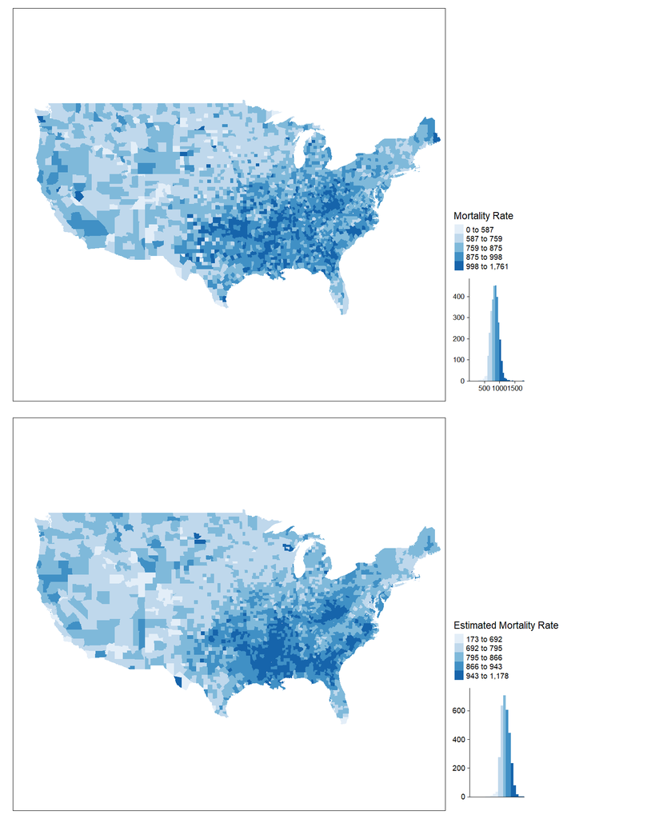

```r
f2<-tm_shape(spdat)+
  tm_polygons("fitted_lag",title="Estimated Mortality Rate",
              border.col = NULL,
              palette="Blues",
              style="kmeans",
              n=5,
              legend.hist=T  )+
  tm_format(format = "World", legend.outside=T)

f2_all<-tmap_arrange(f1, f2, nrow = 2)
f2_all
```